# Mass Shooting Gun Violence in the United States of America

Part I: Exploratory Data Analysis

Trevor Schrotz

November 04, 2022

# Introduction

## Preface

Guns. Gun violence. Gun rights. These are highly contentious and controversial issues that come with a host of prior tuning effects on individual opinions and beliefs. What follows is a scientific analysis of mass shooting phenomena in the US.

The intent of this analysis is purely scientific and it has neither political motive nor personal agenda other than to inform people about the state of mass shooting gun violence in the United States of America.

An open and scientific mind was applied to data to produce information about the aforementioned phenomena both as a learning experience for the author and an informative experience for the public.

## Overview

Gun violence is a pervasive issue in American culture. This analysis focuses on mass shootings in particular, and it does not include all types of US gun-related incidents. A mass shooting is defined by the Federal Bureau of Investigation as a shooting in which four or more people are injured or killed not including the perpatrator(s) of the shooting. The source of these data is the Gun Violence Archive, and the original sources of the shootings are news media reports and law enforcement reports.

The entire project is in four sections. This first one is exploratory data analysis to gather an understanding of the data. The second part is abour mapping mass shootings. The third is about time series analysis, and the fourth is about machine learning.

# Setup

## Load Libraries

We begin by loading in libraries that help with the data handling and analytical process.

```r
library(tidyverse)
library(tidymodels)
library(tidytext)
library(lubridate)
library(scales)
library(janitor)
library(skimr)
library(tidyquant)
library(broom)
library(purrr)
library(rvest)
library(tidycensus)
library(tidygeocoder)
library(leaflet)
library(knitr)
api_key <- Sys.getenv("CENSUS_API_KEY")
```

## Source Data from the GVA

To get the prolific amount of data from the GVA website, we can employ web scraping to read the html and turn it into a tidy tabular format for analysis. I originally began this project as a way to learn web scraping, and the project evolved into the desire to learn even more as I explored the data.

The GVA URLs were different by year, and they even changed during the course of this project. I decided to break the scraping up by year as that is how the website is organized to some extent.

```r
#2014

# create a tibble with a column of the website page names that we want to scrape
ms_pages_2014 <-
    tibble(pages = c("https://www.gunviolencearchive.org/reports/mass-shootings/2014",
                                  str_c("https://www.gunviolencearchive.org/reports/mass-shootings/2014?page=",c(1:10))))

# use the purrr package to iterate over the column of URLs using the function from the xml2 package
ms_scrape_2014 <- ms_pages_2014 %>%
    mutate(scrape = map(.x = pages, .f = ~read_html(.x)))

# convert the html into a table again using purrr's map function to interate over the scraped data
ms_2014_tbl <- map_df(ms_scrape_2014$scrape, ~ html_table(.x))

# repeat for additional URLs
#2015
ms_pages_2015 <-
    tibble(pages = c("https://www.gunviolencearchive.org/reports/mass-shootings/2015",
                                  str_c("https://www.gunviolencearchive.org/reports/mass-shootings/2015?page=",c(1:13))))

ms_scrape_2015 <- ms_pages_2015 %>%
    mutate(scrape = map(.x = pages, .f = ~read_html(.x)))

ms_2015_tbl <- map_df(ms_scrape_2015$scrape, ~ html_table(.x))


#2016
ms_pages_2016 <-
    tibble(pages = c("https://www.gunviolencearchive.org/reports/mass-shooting?year=2016",
                                  str_c("https://www.gunviolencearchive.org/reports/mass-shooting?page=",c(1:15),"&year=2016")))

ms_scrape_2016 <- ms_pages_2016 %>%
    mutate(scrape = map(.x = pages, .f = ~read_html(.x)))

ms_2016_tbl <- map_df(ms_scrape_2016$scrape, ~ html_table(.x))


#2017
ms_pages_2017 <-
    tibble(pages = c("https://www.gunviolencearchive.org/reports/mass-shooting?year=2017",
                                  str_c("https://www.gunviolencearchive.org/reports/mass-shooting?page=",c(1:13),"&year=2017")))

ms_scrape_2017 <- ms_pages_2017 %>%
    mutate(scrape = map(.x = pages, .f = ~read_html(.x)))

ms_2017_tbl <- map_df(ms_scrape_2017$scrape, ~ html_table(.x))


#2018
ms_pages_2018 <-
    tibble(pages = c("https://www.gunviolencearchive.org/reports/mass-shooting?year=2018",
                                  str_c("https://www.gunviolencearchive.org/reports/mass-shooting?page=",c(1:13),"&year=2018")))

ms_scrape_2018 <- ms_pages_2018 %>%
    mutate(scrape = map(.x = pages, .f = ~read_html(.x)))

ms_2018_tbl <- map_df(ms_scrape_2018$scrape, ~ html_table(.x))


#2019
ms_pages_2019 <-
    tibble(pages = c("https://www.gunviolencearchive.org/reports/mass-shooting?year=2019",
                                  str_c("https://www.gunviolencearchive.org/reports/mass-shooting?page=",c(1:16),"&year=2019")))

ms_scrape_2019 <- ms_pages_2019 %>%
    mutate(scrape = map(.x = pages, .f = ~read_html(.x)))

ms_2019_tbl <- map_df(ms_scrape_2019$scrape, ~ html_table(.x))


#2019 through 2022
ms_pages_2019_2022 <-
    tibble(pages = c("https://www.gunviolencearchive.org/mass-shooting",
                                       str_c("https://www.gunviolencearchive.org/mass-shooting?page=",c(1:80))))


ms_scrape_2019_2022 <- ms_pages_2019_2022 %>%
    mutate(scrape = map(.x = pages, .f = ~read_html(.x)))

ms_2019_2022_tbl <- map_df(ms_scrape_2019_2022$scrape, ~ html_table(.x))
```

## Data Preparation

Once I have collected the different years, we can stack the scraped datasets, and then store the file locally so that we don’t need to continually call on the website.

```r
complete_tbl <- ms_2014_tbl %>%
    bind_rows(ms_2015_tbl) %>%
    bind_rows(ms_2016_tbl) %>%
    bind_rows(ms_2017_tbl) %>%
    bind_rows(ms_2018_tbl) %>%
    bind_rows(ms_2019_tbl) %>%
    bind_rows(ms_2019_2022_tbl) %>%
    distinct()

write_rds(complete_tbl, "gva_data.rds")
```

Now we can read in the saved data file locally.

```r
complete_tbl <- read_rds("gva_data.rds")
```

Here I prepare the primary data set to include some date-related fields for convenience when plotting and summarizing the data.

```r
ms_tbl <- complete_tbl %>%
    janitor::clean_names() %>%
    select(-operations) %>%
    mutate(incident_date = mdy(incident_date),
           year = year(incident_date),
           month = month(incident_date, label = T, abbr = T),
           incident_month = rollforward(incident_date),
           dow = wday(incident_date, label = TRUE)) %>%
    arrange(incident_date)
```

## Grouping and Summarizing Function

This is a function to group and summarize the data in different ways since we will need to do this many times later. Function are very helpful in R particularly when you need to do the same thing over and over.

```r
group_function <- function(df, ...) {

    output <- df %>%
        group_by(...) %>%
        summarize(n_incidents = n(),
                  n_deaths = sum(number_killed, na.rm = T),
                  n_injuries = sum(number_injured, na.rm = T),
                  .groups = "drop")

    return(output)
}
```

# The Data

## First Look

An initial look at a sample of ten rows of the data. Each row represents one mass shooting incident. Each incident has its own unique ID, a date, geographic location, and statistics about the number of injuries and deaths as well as some date related data that I added above to assist with analysis.

```r
ms_tbl %>%
    sample_n(size = 10)
```

| incident_id | incident_date | state | city_or_county | address | number_killed | number_injured | year | month | incident_month | dow |
| --- | --- | --- | --- | --- | --- | --- | --- | --- | --- | --- |
| 2434151 | 2022-10-08 | Missouri | Saint Joseph | 302 Illinois Ave | 0 | 4 | 2022 | Oct | 2022-10-31 | Sat |
| 1774123 | 2020-08-24 | Michigan | Detroit | 11938 E McNichols Rd | 0 | 4 | 2020 | Aug | 2020-08-31 | Mon |
| 809683 | 2017-04-02 | Iowa | Des Moines | 2500 Martin Luther King Jr. Parkway | 0 | 5 | 2017 | Apr | 2017-04-30 | Sun |
| 2315150 | 2022-05-29 | Oklahoma | Taft | 104 Elm St | 1 | 7 | 2022 | May | 2022-05-31 | Sun |
| 559042 | 2016-05-14 | Georgia | Atlanta | Cordova and Peoples Street | 0 | 5 | 2016 | May | 2016-05-31 | Sat |
| 2280875 | 2022-04-17 | South Carolina | Furman | 72 Ashley Circle Rd | 0 | 9 | 2022 | Apr | 2022-04-30 | Sun |
| 1511999 | 2019-09-24 | Illinois | Chicago | 2000 block of South Hoyne Ave | 1 | 3 | 2019 | Sep | 2019-09-30 | Tue |
| 2298836 | 2022-05-10 | Illinois | Chicago | 4800 block of S Ada St | 1 | 4 | 2022 | May | 2022-05-31 | Tue |
| 1703509 | 2020-06-12 | Pennsylvania | Philadelphia | N Broad St and Colwyn St | 0 | 6 | 2020 | Jun | 2020-06-30 | Fri |
| 2154441 | 2021-10-30 | Oklahoma | Oklahoma City | NW 122nd St and N Council Rd | 0 | 4 | 2021 | Oct | 2021-10-31 | Sat |

```r
skim(ms_tbl)
```

Data summary

| Name | ms_tbl |
| --- | --- |
| Number of rows | 3975 |
| Number of columns | 11 |
| _______________________ |  |
| Column type frequency: |  |
| character | 3 |
| Date | 2 |
| factor | 2 |
| numeric | 4 |
| ________________________ |  |
| Group variables | None |

**Variable type: character**

| skim_variable | n_missing | complete_rate | min | max | empty | n_unique | whitespace |
| --- | --- | --- | --- | --- | --- | --- | --- |
| state | 0 | 1 | 4 | 20 | 0 | 49 | 0 |
| city_or_county | 0 | 1 | 3 | 39 | 0 | 1027 | 0 |
| address | 0 | 1 | 3 | 54 | 0 | 3924 | 0 |

**Variable type: Date**

| skim_variable | n_missing | complete_rate | min | max | median | n_unique |
| --- | --- | --- | --- | --- | --- | --- |
| incident_date | 0 | 1 | 2014-01-01 | 2022-11-04 | 2019-09-24 | 1978 |
| incident_month | 0 | 1 | 2014-01-31 | 2022-11-30 | 2019-09-30 | 107 |

**Variable type: factor**

| skim_variable | n_missing | complete_rate | ordered | n_unique | top_counts |
| --- | --- | --- | --- | --- | --- |
| month | 0 | 1 | TRUE | 12 | Jul: 514, Jun: 482, Aug: 429, Sep: 383 |
| dow | 0 | 1 | TRUE | 7 | Sun: 1118, Sat: 944, Fri: 451, Mon: 394 |

**Variable type: numeric**

| skim_variable | n_missing | complete_rate | mean | sd | p0 | p25 | p50 | p75 | p100 | hist |
| --- | --- | --- | --- | --- | --- | --- | --- | --- | --- | --- |
| incident_id | 0 | 1 | 1395987.17 | 713699.86 | 92194 | 742271.5 | 1515312 | 2038020 | 2452501 | ▅▅▅▆▇ |
| number_killed | 0 | 1 | 1.05 | 1.99 | 0 | 0.0 | 1 | 1 | 59 | ▇▁▁▁▁ |
| number_injured | 0 | 1 | 4.18 | 7.31 | 0 | 3.0 | 4 | 5 | 441 | ▇▁▁▁▁ |
| year | 0 | 1 | 2018.71 | 2.54 | 2014 | 2017.0 | 2019 | 2021 | 2022 | ▃▅▂▆▇ |

## Initial Summaries

- Since 2014, there have been 3,975 mass shootings, 4,191 people have died, and there have been 16,612 injuries.
- There is about one death per mass shooting on average.
- There are about four injuries per mass shooting event on average.
- There are four times more injuries than deaths (4:1 per incident on average).

```r
ms_tbl %>%
    group_function() %>%
    mutate(inj_death_ratio = n_injuries / n_deaths,
           death_inc_ratio = n_deaths / n_incidents,
           inj_inc_ratio = n_injuries / n_incidents)
```

| n_incidents | n_deaths | n_injuries | inj_death_ratio | death_inc_ratio | inj_inc_ratio |
| --- | --- | --- | --- | --- | --- |
| 3975 | 4191 | 16612 | 3.963732 | 1.05434 | 4.179119 |

# Plots and Visualizations

## Mass Shooting Volume and Trend

Here we see a couple of patterns. First, the volume of mass shootings is increasing. Second, there appears to be a seasonal component to when mass shootings occur meaning there is a tendency and pattern to mass shooting volume consistent with the month of the year.

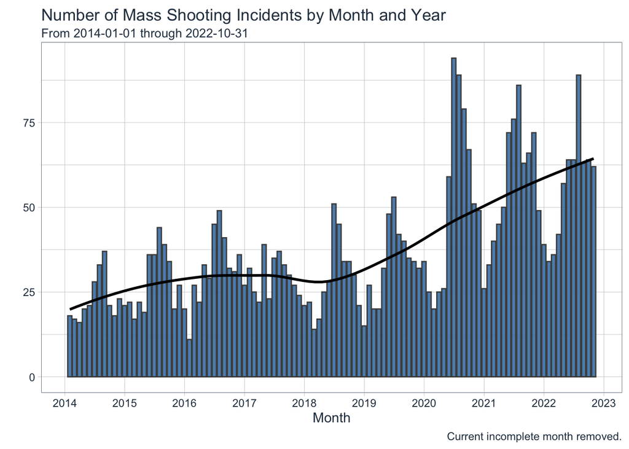

```r
ms_tbl %>%
    filter(incident_month < floor_date(Sys.Date(), "month")) %>%
    group_function(incident_month) %>%
    ggplot(aes(incident_month, n_incidents)) +
    geom_col(fill = "steelblue", color = "gray30", alpha = 0.9) +
    geom_smooth(method = "loess", se = FALSE, color = "black") +
    scale_x_date(date_labels = "%Y", date_breaks = "1 year") +
    theme_tq() +
    scale_color_tq() +
    labs(title = "Number of Mass Shooting Incidents by Month and Year",
         subtitle = str_glue("From {min(ms_tbl$incident_date)} through {max(ms_tbl %>% filter(incident_month < floor_date(Sys.Date(), 'month')) %>% pull(incident_date))}"),
         x = "Month",
         y = "",
         caption = "Current incomplete month removed.")
```

## Annual Growth Rate Table

How much have mass shooting incidents, deaths, and injuries been changing over time? To find out, we can use the geometric mean on the annual rates of change to get a percentage increase or decrease from the prior year.

```r
growth_rates <- ms_tbl %>%
    filter(year(incident_date) < year(Sys.Date())) %>%
    group_function(year) %>%
    mutate(across(c(n_incidents:n_injuries), ~. / lag(.), .names = "{.col}_delta")) %>%
    drop_na()

gr_table <- growth_rates %>%
    select(year, contains("delta")) %>%
    mutate(across(contains("delta"), ~. - 1))

gr_table %>%
    mutate(across(contains("delta"), ~percent(., accuracy = 0.1))) %>%
    gt::gt()
```

| year | n_incidents_delta | n_deaths_delta | n_injuries_delta |
| --- | --- | --- | --- |
| 2015 | 23.1% | 34.2% | 23.1% |
| 2016 | 14.0% | 22.8% | 15.1% |
| 2017 | -9.1% | -2.6% | 17.4% |
| 2018 | -3.4% | -15.6% | -26.4% |
| 2019 | 24.1% | 25.0% | 28.7% |
| 2020 | 46.3% | 10.3% | 48.4% |
| 2021 | 13.3% | 37.4% | 11.5% |

## Annual Growth Rate Graphic

This chart shows how the volume of mass shootings and the resulting deaths and injuries have either increased or decreased over the years. Anything above zero is an increase from the prior year, and anything below zero is a decrease.

Only two years (2017 and 2018) saw a modest decrease in the number of mass shootings and every other year has seen growth. Deaths decreased modestly in two years (2017 and 2018), but increased in all other years, and injuries only saw one year of decrease (2018)

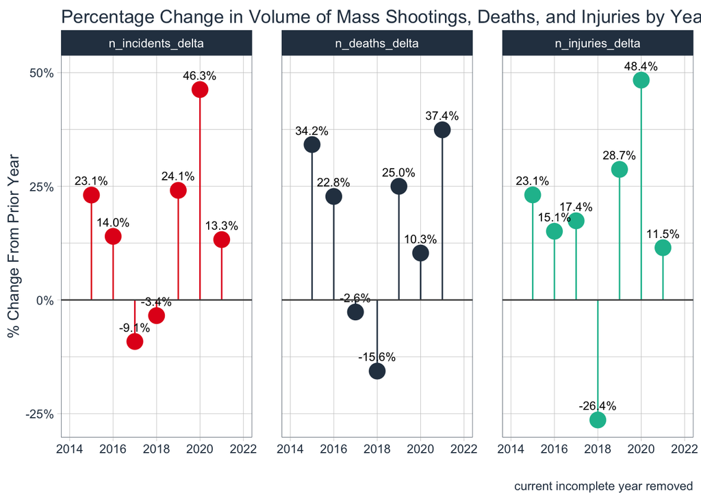

```r
gr_table %>%
    pivot_longer(cols = contains("delta")) %>%
    ggplot(aes(year, value, color = name)) +
    geom_segment(aes(x = year, xend = year, y = 0, yend = value)) +
    geom_point(size = 5) +
    geom_text(aes(label = percent(value, accuracy = 0.1)), size = 3, color = "black", vjust = -1.2) +
    geom_hline(yintercept = 0, color = "gray30") +
    expand_limits(x = c(2014, 2022), y = c(-0.25, 0.5)) +
    scale_y_continuous(labels = label_percent(accuracy = 1)) +
    theme_tq() +
    scale_color_tq() +
    facet_grid(~fct_inorder(name)) +
    labs(title = "Percentage Change in Volume of Mass Shootings, Deaths, and Injuries by Year",
         x = "",
         y = "% Change From Prior Year",
         caption = "current incomplete year removed") +
    theme(legend.position = "none")
```

## Total Growth Rate

This is the average growth rate over the entire period of time in total. Effectively, you can read this summary as the annual average increase in the number of incidents, deaths, and injuries since 2014. On average, mass shoooting incidents, deaths, and injuries have been growing at a rate of ~14% per year since 2014.

```r
gr_table %>%
    mutate("Start Year" = min(year)-1,
           "End Year" = max(year)) %>%
    group_by(`Start Year`, `End Year`) %>%
    summarize(across(contains("delta"), ~exp(mean(log(. + 1))) - 1),
              .groups = "drop") %>%
    mutate(across(contains("delta"), ~percent(., accuracy = 0.1))) %>%
    pivot_longer(cols = contains("delta"), names_to = "Type", values_to = "Growth Rate") %>%
    gt::gt()
```

| Start Year | End Year | Type | Growth Rate |
| --- | --- | --- | --- |
| 2014 | 2021 | n_incidents_delta | 14.2% |
| 2014 | 2021 | n_deaths_delta | 14.4% |
| 2014 | 2021 | n_injuries_delta | 14.7% |

## Incidents Annual Volume

How many mass shootings do we see each year?

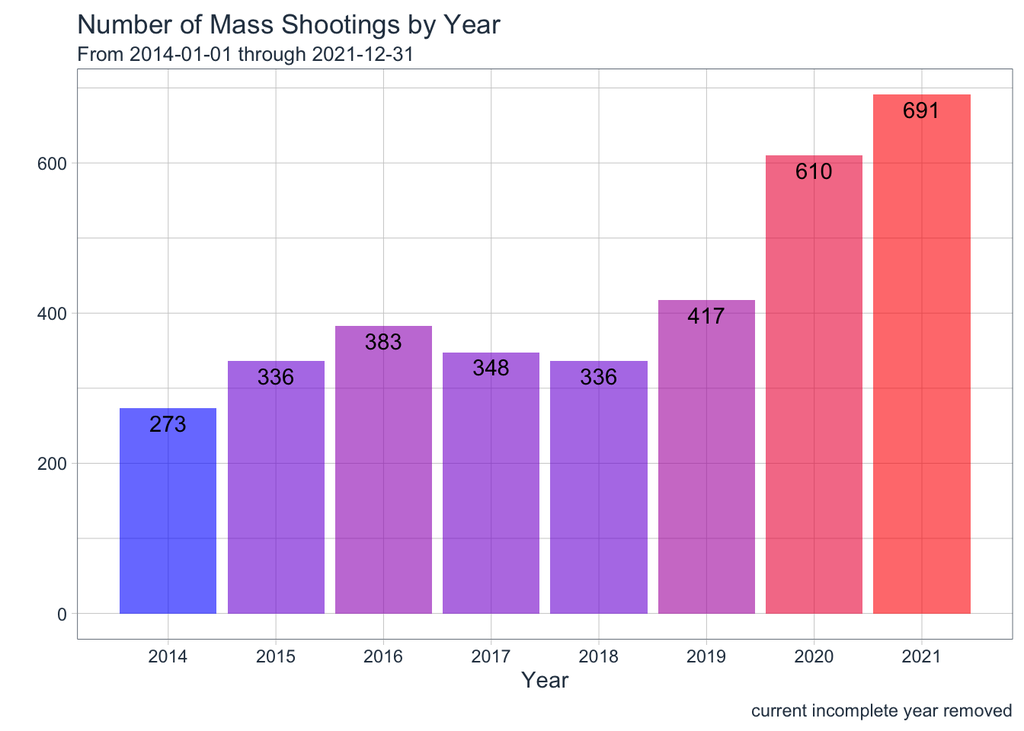

```r
ms_tbl %>%
    filter(year(incident_date) < year(Sys.Date())) %>%
    group_function(year) %>%
    ggplot(aes(year, n_incidents, fill = n_incidents)) +
    geom_col(alpha = 0.6) +
    geom_text(aes(label = n_incidents), nudge_y = -20) +
    theme_tq() +
    scale_fill_gradient(high = "red", low = "blue") +
    scale_x_continuous(breaks = seq(min(ms_tbl$year), max(ms_tbl$year), by = 1)) +
    labs(title = "Number of Mass Shootings by Year",
         subtitle = str_glue("From {min(ms_tbl %>% filter(year < year(Sys.Date())) %>% pull(incident_date))} through {max(ms_tbl %>% filter(year < year(Sys.Date())) %>% pull(incident_date))}"),
         x = "Year",
         y = "",
         caption = "current incomplete year removed") +
    theme(legend.position = "none")
```

## Incidents by Month

Which months tend to have more or less mass shootings?

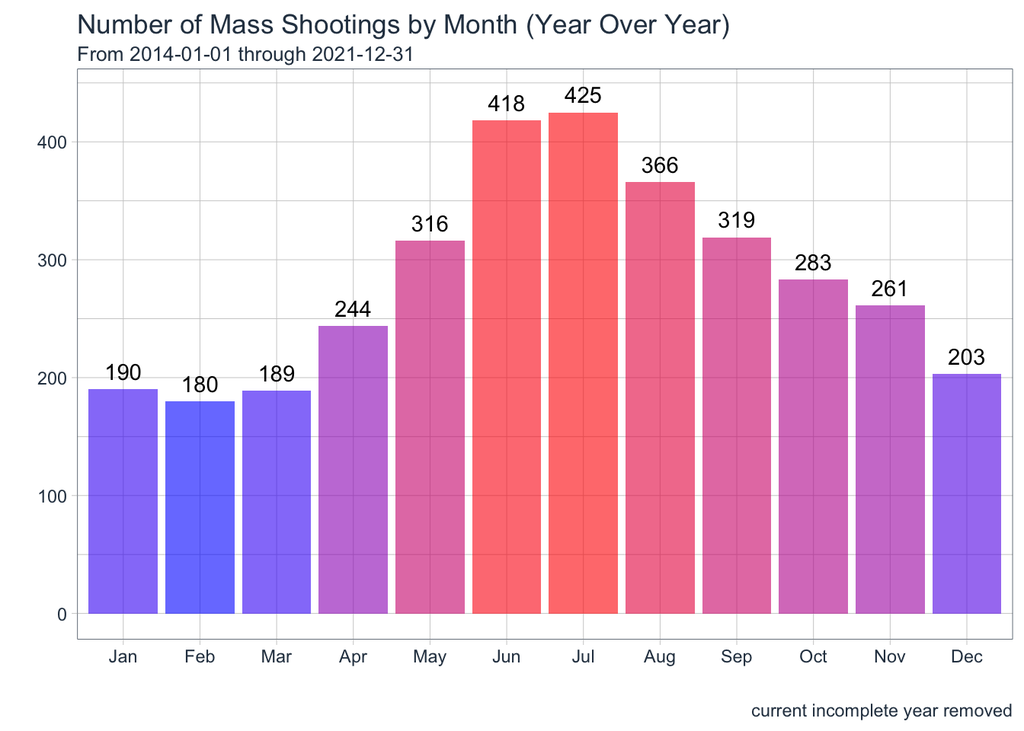

```r
ms_tbl %>%
    filter(year(incident_date) < year(Sys.Date())) %>%
    group_function(month) %>%
    ggplot(aes(month, n_incidents, fill = n_incidents)) +
    geom_col(alpha = 0.6) +
    geom_text(aes(label = n_incidents), nudge_y = 15) +
    theme_tq() +
    scale_fill_gradient(high = "red", low = "blue") +
    labs(title = "Number of Mass Shootings by Month (Year Over Year)",
         subtitle = str_glue("From {min(ms_tbl %>% filter(year < year(Sys.Date())) %>% pull(incident_date))} through {max(ms_tbl %>% filter(year < year(Sys.Date())) %>% pull(incident_date))}"),
         x = "",
         y = "",
         caption = "current incomplete year removed") +
    theme(legend.position = "none")
```

## Incidents by Weekday

Which days of the week tend to have more or less mass shootings?

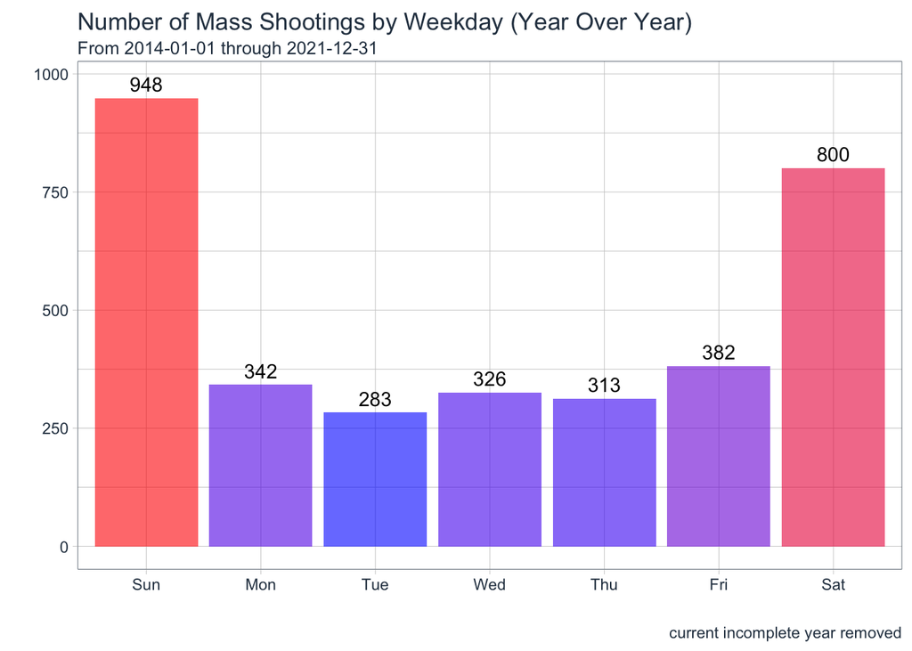

```r
ms_tbl %>%
    filter(year(incident_date) < year(Sys.Date())) %>%
    group_function(dow) %>%
    ggplot(aes(dow, n_incidents, fill = n_incidents)) +
    geom_col(alpha = 0.6) +
    geom_text(aes(label = n_incidents), nudge_y = 30) +
    theme_tq() +
    scale_fill_gradient(high = "red", low = "blue") +
    labs(title = "Number of Mass Shootings by Weekday (Year Over Year)",
         subtitle = str_glue("From {min(ms_tbl %>% filter(year < year(Sys.Date())) %>% pull(incident_date))} through {max(ms_tbl %>% filter(year < year(Sys.Date())) %>% pull(incident_date))}"),
         x = "",
         y = "",
         caption = "current incomplete year removed") +
    theme(legend.position = "none")
```

## Month and Weekday Proportions

Here is one more visualization to help us see the number of mass shootings by day of the week and the month in which they occur. Each row of bars represents 100% of the shootings in the given days and months.

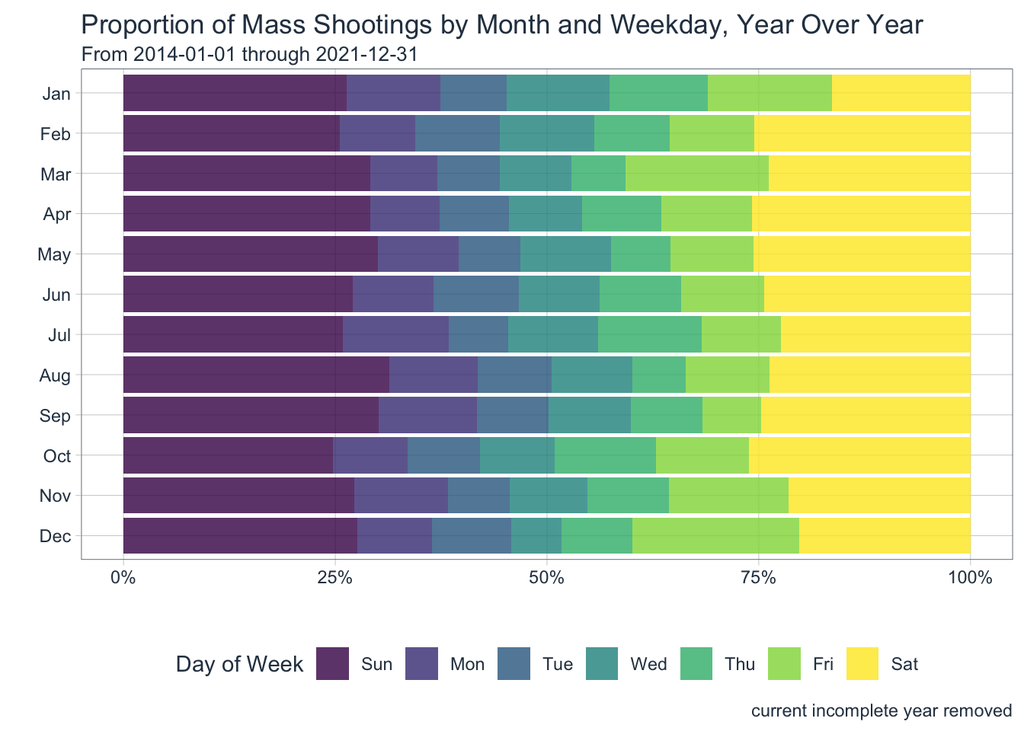

```r
ms_tbl %>%
    filter(year(incident_date) < year(Sys.Date())) %>%
    group_function(month, dow) %>%
    select(month:n_incidents) %>%
    ggplot(aes(fct_rev(month), n_incidents, fill = dow)) +
    geom_col(position = position_fill(reverse = TRUE), alpha = 0.8) +
    coord_flip() +
    scale_y_continuous(labels = scales::label_percent(accuracy = 1)) +
    theme_tq() +
    labs(title = "Proportion of Mass Shootings by Month and Weekday, Year Over Year",
         subtitle = str_glue("From {min(ms_tbl %>% filter(year < year(Sys.Date())) %>% pull(incident_date))} through {max(ms_tbl %>% filter(year < year(Sys.Date())) %>% pull(incident_date))}"),
         x = "",
         y = "",
         caption = "current incomplete year removed",
         fill = "Day of Week") +
    guides(fill = guide_legend(nrow = 1, byrow = TRUE))
```

## Relationships Between Variables

### Chi-Squared Test - Weekday vs Month

We have seen that there are some days that have higher numbers of mass shootings as well as some months that are higher than others. That creates questions.

First, is there a statistically significant relationship between the day of the week when a mass shooting occurs and the month in which the shooting happens?

We can use a chi-squared test of independence to test our question.

```r
chi_tbl <- ms_tbl %>%
    filter(year(incident_date) < year(Sys.Date())) %>%
    group_function(incident_id, month, dow) %>%
    select(month:n_incidents)

chi_tbl %>%
    table()
```

```
## , , n_incidents = 1
##
##      dow
## month Sun Mon Tue Wed Thu Fri Sat
##   Jan  50  21  15  23  22  28  31
##   Feb  46  16  18  20  16  18  46
##   Mar  55  15  14  16  12  32  45
##   Apr  71  20  20  21  23  26  63
##   May  95  30  23  34  22  31  81
##   Jun 113  40  42  40  40  41 102
##   Jul 110  53  30  45  52  40  95
##   Aug 115  38  32  35  23  36  87
##   Sep  96  37  27  31  27  22  79
##   Oct  70  25  24  25  34  31  74
##   Nov  71  29  19  24  25  37  56
##   Dec  56  18  19  12  17  40  41
```

```r
chisq_test(x = chi_tbl, formula = dow ~ month)
```

| statistic | chisq_df | p_value |
| --- | --- | --- |
| 77.12579 | 66 | 0.1645196 |

The answer is that we don’t have enough evidence to support the hypothesis that there is a significant relationship between the mass shooting day of the week and the month in which is occurs. The Sundays in Jun, Jul, and Aug stand out with higher volumes, but there isn’t a statistically significant difference in those months and days of the week at the p < 0.05 significance level.

### Seasonal Statistics

Follow up question. What proportion of shootings happen in the different sesaons (roughly approximated by season starting month)?

```r
ms_tbl %>%
    filter(year(incident_date) < year(Sys.Date())) %>%
    group_function(incident_id, month) %>%
    select(month:n_incidents) %>%
    summarize(n = n(),
              winter = sum(n_incidents[month %in% c("Dec","Jan","Feb")]),
              spring = sum(n_incidents[month %in% c("Mar","Apr","May")]),
              summer = sum(n_incidents[month %in% c("Jun","Jul","Aug")]),
              fall =   sum(n_incidents[month %in% c("Sep","Oct","Nov")]),
              .groups = "drop") %>%
    mutate(spring_prop = spring / n,
           summer_prop = summer / n,
           fall_prop = fall / n,
           winter_prop = winter / n) %>%
    select(contains("prop")) %>%
    mutate(across(everything(), ~ percent(., accuracy = 0.1)))
```

| spring_prop | summer_prop | fall_prop | winter_prop |
| --- | --- | --- | --- |
| 22.1% | 35.6% | 25.4% | 16.9% |

Mass shootings are approximately 10% more common in the summer months and approximately 10% less likely in the winter when compared to spring and fall months.

### Chi-Squared Test - Weekday

Second, is there a significant difference in the number of mass shootings by the day of the week? Again, we can use a chi-squared test checking for the goodness of fit where we essentially test the assumption that there is no difference in the proportion of mass shootings by day of the week. In other words, each day should have proportionally the same volume of mass shootings.

```r
chi_dow_tbl <- ms_tbl %>%
    filter(year(incident_date) < year(Sys.Date())) %>%
    group_function(incident_id, dow) %>%
    select(dow:n_incidents)

chi_dow_tbl %>% table()
```

```
##      n_incidents
## dow     1
##   Sun 948
##   Mon 342
##   Tue 283
##   Wed 326
##   Thu 313
##   Fri 382
##   Sat 800
```

```r
chisq_test(chi_dow_tbl,
           response = dow,
           p = c("Sun" = 1/7,
                 "Mon" = 1/7,
                 "Tue" = 1/7,
                 "Wed" = 1/7,
                 "Thu" = 1/7,
                 "Fri" = 1/7,
                 "Sat" = 1/7))
```

| statistic | chisq_df | p_value |
| --- | --- | --- |
| 908.1456 | 6 | 6.513779e-193 |

The answer here is yes, there is a significant difference in the volume of mass shooting incidents in different days of the week.

### Weekend Proportion

Follow up question. What is the proportion of weekend mass shootings?

```r
ms_tbl %>%
    filter(year(incident_date) < year(Sys.Date())) %>%
    group_function(incident_id, dow) %>%
    select(dow:n_incidents) %>%
    summarize(n = n(),
              sat_sun = sum(n_incidents[dow %in% c("Sat","Sun")]),
              .groups = "drop") %>%
    transmute(weekend_prop = sat_sun / n,
              weekend_prop = percent(weekend_prop, accuracy = 0.1))
```

| weekend_prop |
| --- |
| 51.5% |

About 51% of mass shootings occur on weekends.

## Seasonality and Trend Exploration

We noted before that there are seasonal trends in the data, so I am going to bring those forward using moving averages which are simply an average of the volume of mass shootings over a given window of time. In this case, I will use two windows - one for a six month moving average to highlight the seasonality, and a second moving average of 12 months to highlight the trend of increasing numbers of mass shootings. We appear to have a new post-pandemic normal.

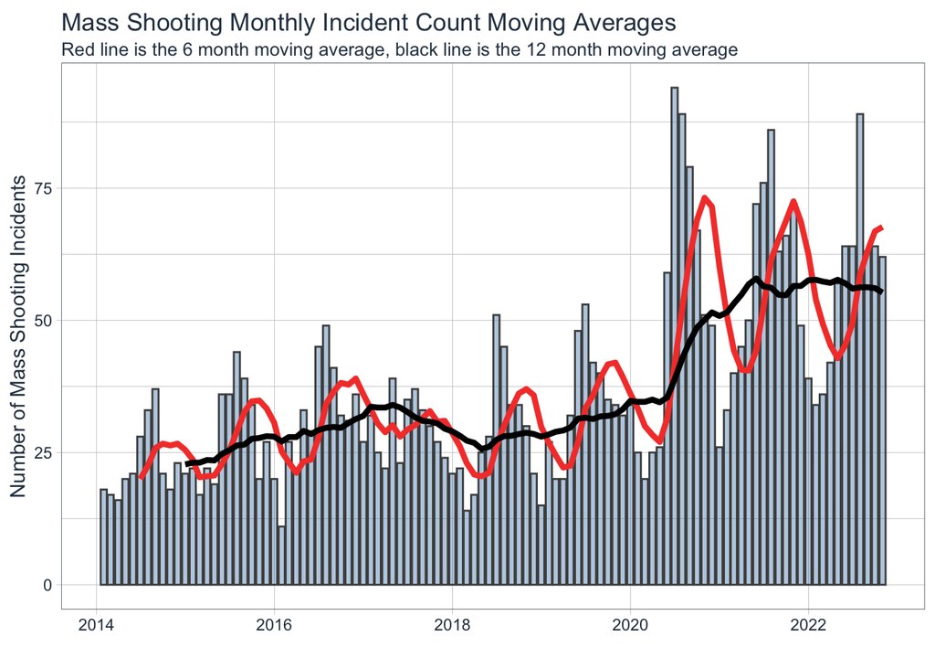

```r
#this creates a tibble we can use for the moving average analysis

ma_tbl <- ms_tbl %>%
    filter(incident_date < floor_date(Sys.Date(), "month")) %>%
    arrange(incident_date) %>%
    group_function(incident_month)

ma_tbl %>%
    ggplot(aes(incident_month, n_incidents)) +
    geom_col(fill = "steelblue", color = "gray30", alpha = 0.4) +
    geom_line(data = ma_tbl %>%
                select(1,2) %>%
                mutate(ma_6 = rollmean(n_incidents, k = 6, fill = NA, align = "right")),
                aes(incident_month, ma_6), color = "#F44336", size = 1.5) +
    geom_line(data = ma_tbl %>%
                select(1,2) %>%
                mutate(ma_12 = rollmean(n_incidents, k = 12, fill = NA, align = "right")),
                aes(incident_month, ma_12), color = "black", size = 1.5)+
    theme_tq() +
    scale_color_tq() +
    labs(title = "Mass Shooting Monthly Incident Count Moving Averages",
         subtitle = "Red line is the 6 month moving average, black line is the 12 month moving average",
         x = "",
         y = "Number of Mass Shooting Incidents")
```

It’s now clearer to see the increasing trend in the twelve month moving average line in black, and the seasonal monthly trend of the six month moving average in red. You can see how the red line moves above and below the black line clearly revealing the seasonal component of mass shootings.

Additionally, we can also see that since 2020, the variability in the number of mass shootings has increased as the red line goes much higher than in previous years. The is obvious given the increase in volume, but it’s worth noting the change in the total system behavior. Further, whilst 2020 was an aberrant year given the pandemic, assuming a potential relationship between the impact of the pandemic on US society and mass shooting behavior, the prevalence has not returned back to pre-pandemic levels given that we are now in a post-pandemic environment.

## Incidents, Deaths, and Injuries by Month

This is a time series that takes incidents as we have seen previously and lays out deaths and injury volume by month.

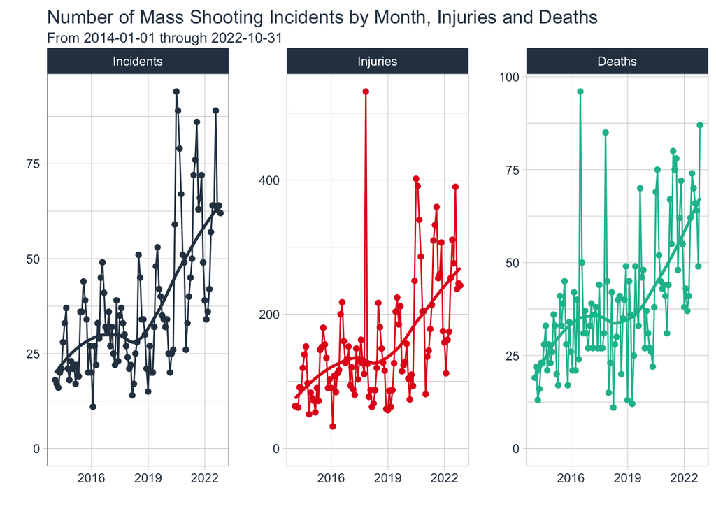

```r
ms_tbl %>%
    filter(incident_month < floor_date(Sys.Date(), "month")) %>%
    group_function(incident_month) %>%
    rename("Incidents" = n_incidents,"Deaths" = n_deaths,"Injuries" = n_injuries) %>%
    pivot_longer(cols = -1) %>%
    mutate(name = factor(name, levels = c("Incidents","Injuries","Deaths"))) %>%
    ggplot(aes(incident_month, value, group = name, color = name)) +
    geom_line() +
    geom_point() +
    geom_smooth(method = "loess", se = FALSE) +
    scale_x_date(date_labels = "%Y", date_breaks = "3 years") +
    expand_limits(y = 0) +
    theme_tq() +
    scale_color_tq() +
    facet_wrap(~ name, scales = "free_y") +
    labs(title = "Number of Mass Shooting Incidents by Month, Injuries and Deaths",
         subtitle = str_glue("From {min(ms_tbl$incident_date)} through {max(ms_tbl %>% filter(incident_month < floor_date(Sys.Date(), 'month')) %>% pull(incident_date))}"),
         x = "",
         y = "") +
    theme(legend.position = "none")
```

# US States

## States with No Mass Shootings

Is there a state that has not had a mass shooting?

```r
us_states <- tibble("state" = state.name) %>%
    bind_cols(tibble("state_code" = state.abb)) %>%
    bind_rows(tibble(state = "District of Columbia",
                     state_code = "DC")) %>%
    arrange(state)

ms_states_tbl <- ms_tbl %>%
    inner_join(us_states, by = "state") %>%
    distinct(state_code)

no_mass_shooting_states <- tibble("state_code" = state.abb,
                                  "state_name" = state.name) %>%
    anti_join(ms_states_tbl, by = "state_code") %>%
    pull(state_name)

state_count <- length(no_mass_shooting_states)
```

Yes, 2 states have not had mass shootings since these data were collected beginning in 2014: Hawaii and North Dakota

## States with the Most Mass Shootings

Let’s look a the number of mass shootings by state. This gives us a look at totals.

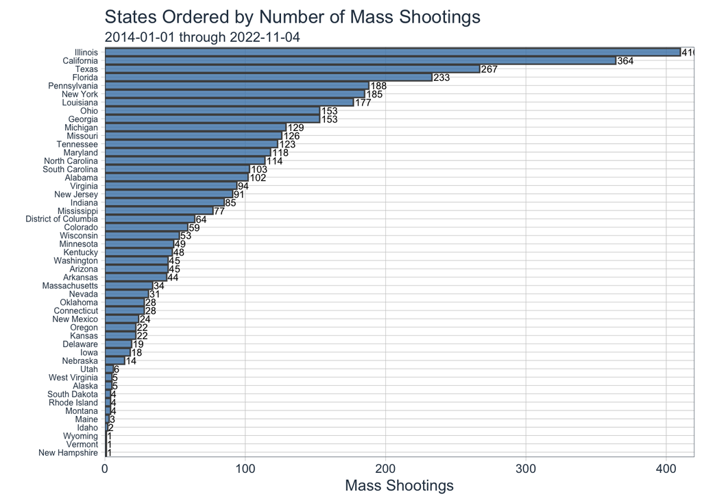

```r
ms_tbl %>%
    group_function(state) %>%
    inner_join(us_states, by = "state") %>%
    ggplot(aes(fct_reorder(state, n_incidents), n_incidents)) +
    geom_col(fill = "steelblue", color = "gray30", alpha = 0.8) +
    geom_text(aes(label = n_incidents), hjust = -0.1, size = 2.5) +
    scale_y_continuous(limits = c(0, 420), expand = c(0, 0)) +
    coord_flip() +
    theme_tq() +
    labs(title = "States Ordered by Number of Mass Shootings",
         subtitle = str_glue("{min(ms_tbl$incident_date)} through {max(ms_tbl$incident_date)}"),
         x = "",
         y = "Mass Shootings") +
    theme(axis.text.y = element_text(size = 6))
```

```r
state_stats <- ms_tbl %>%
    group_function(state) %>%
    inner_join(us_states, by = "state") %>%
    mutate(incidents_rank = min_rank(desc(n_incidents)))

top_five_states <- state_stats %>%
    filter(incidents_rank %in% c(1:5)) %>%
    arrange(incidents_rank) %>%
    pull(state)

top_nine_states <- state_stats %>%
    filter(incidents_rank %in% c(1:9)) %>%
    arrange(incidents_rank)

write_csv(top_nine_states, "top_nine_states.csv")
```

The five states with the greatest number of mass shootings are: Illinois, California, Texas, Florida, and Pennsylvania.

We should consider proportionally how likely it is to encounter a mass shooting (or being injured or killed) instead of just looking at the total because each state has widely differing total populations. In other words, given the population of a state, which states have the greatest number of mass shootings (or deaths or injuries) per person? I will use the 2020 US decennial census population data by state and the number of incidents, injuries, and deaths by state in 2021. I am including Washington, D.C. as a state. N.B. Another way to approach this would be to sum all of the years compared to a 2020 population, but I elected to simply choose the most recent complete year on record.

## Top Mass Shootings States Per Capita

Which ten states have the most mass shootings, deaths, or injuries per capita?

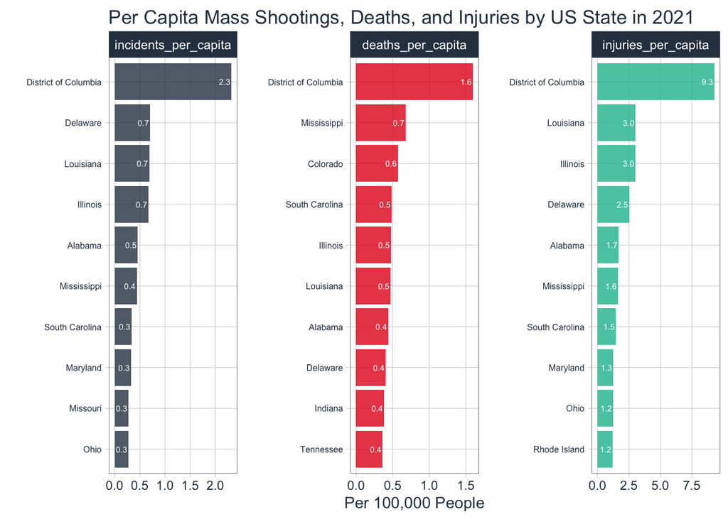

```r
us_state_pop_tbl <- get_decennial(geography = "state",
                       variables = "P1_001N",
                       year = 2020)

per_capita_base <- 1e5

per_capita_tbl <- ms_tbl %>%
    filter(year == 2021) %>%
    group_function(state) %>%
    group_by(state) %>%
    inner_join(us_state_pop_tbl %>%
                   select("state" = NAME, "population" = value), by = "state") %>%
    mutate(incidents_per_capita = n_incidents / (population / per_capita_base),
           deaths_per_capita = n_deaths / (population / per_capita_base),
           injuries_per_capita = n_injuries / (population / per_capita_base))

per_capita_tbl %>%
    select(state, contains("per_capita")) %>%
    pivot_longer(cols = contains("per_capita")) %>%
    mutate(name = fct_relevel(name, c("incidents_per_capita","deaths_per_capita","injuriess_per_capita"))) %>%
    group_by(name) %>%
    slice_max(order_by = value, n = 10) %>%
    ggplot(aes(reorder_within(x = state, by = value, within = name, fun = sum), value, fill = name)) +
    geom_col(alpha = 0.8) +
    geom_text(aes(label = comma(value, accuracy = 0.1)), size = 2, hjust = 1.1, color = "white") +
    coord_flip() +
    facet_wrap(~ name, scales = "free") +
    scale_x_reordered() +
    scale_y_continuous(label = label_comma(accuracy = 0.1)) +
    theme_tq() +
    scale_fill_tq() +
    labs(title = "Per Capita Mass Shootings, Deaths, and Injuries by US State in 2021",
         x = "",
         y = "Per 100,000 People") +
    theme(axis.text.y = element_text(size = 6),
          legend.position = "none")
```

# US Cities

## Top 12 Cities

Which cities tend to see the most mass shooting incidents since 2014? Are they changing over time?

Twelve seems like an odd number to choose, but it just happens to plot better.

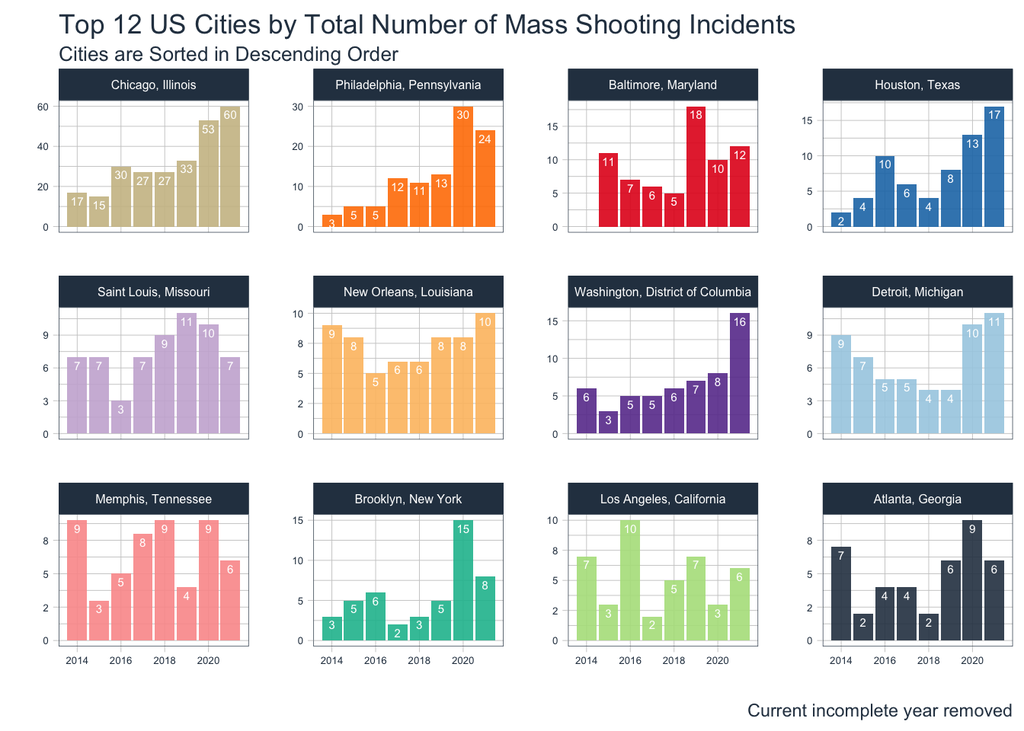

```r
top_cities <- ms_tbl %>%
    filter(year < year(Sys.Date())) %>%
    group_by(state, city_or_county) %>%
    summarize(number_incidents = n(),
              number_killed = sum(number_killed),
              number_injured = sum(number_injured),
              .groups = "drop") %>%
    slice_max(order_by = number_incidents, n = 12) %>%
    distinct(state, city_or_county) %>%
    transmute(city_list = str_c(city_or_county, state, sep = ", "))

top_cities_incidents <- ms_tbl %>%
    mutate(city_list = str_c(city_or_county, state, sep = ", ")) %>%
    filter(year < year(Sys.Date()),
           city_list %in% top_cities$city_list) %>%
    group_by(state, city_or_county, year) %>%
    summarize(number_incidents = n(),
              number_killed = sum(number_killed),
              number_injured = sum(number_injured),
              .groups = "drop") %>%
    complete(year, nesting(state, city_or_county),
             fill = list(number_incidents = 0, number_killed = 0, number_injured = 0)) %>%
    ungroup()

top_cities_incidents %>%
    ggplot(aes(year, number_incidents, fill = city_or_county)) +
    geom_col(alpha = 0.9) +
    geom_text(aes(label = number_incidents), fill = "white", vjust = 1.5, size = 2, color = "white") +
    facet_wrap(~ fct_reorder(str_c(city_or_county, state, sep = ", "), -number_incidents, sum), scales = "free_y") +
    expand_limits(y = 0) +
    theme_tq() +
    scale_fill_tq() +
    scale_y_continuous(labels = label_comma(accuracy = 1)) +
    labs(x = "",
         y = "",
         title = str_glue("Top {length(unique(top_cities_incidents$state))} US Cities by Total Number of Mass Shooting Incidents"),
         subtitle = "Cities are Sorted in Descending Order",
         caption = "Current incomplete year removed") +
    theme(legend.position = "none",
          strip.text.x = element_text(size = 6),
          axis.text.x = element_text(size = 5),
          axis.text.y = element_text(size = 5))
```

## US Cities with 20+ Mass Shootings

Which cities have had more than 20 mass shootings since 2014?

### Selection Criteria - Why 20?

The number 20 is somewhat arbitrary, but when looking at the counts of incidents by city, 20 seems to be near an inflection point at which the prevalence of mass shootings in a given city becomes significantly higher. Ten would have also been a reasonable threshold to choose.

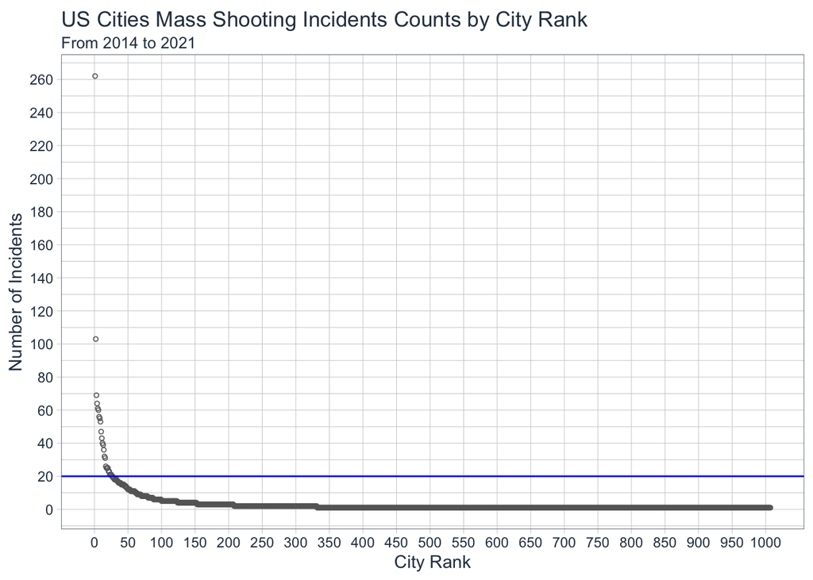

```r
ranked_cities <- ms_tbl %>%
    filter(year < year(Sys.Date())) %>%
    inner_join(us_states, by = "state") %>%
    group_by(city = str_c(city_or_county, state_code, sep = ", ")) %>%
    summarize(number_incidents = n(),
              number_killed = sum(number_killed),
              number_injured = sum(number_injured),
              min_year = min(year),
              max_year = max(year),
              .groups = "drop") %>%
    arrange(desc(number_incidents)) %>%
    mutate(rank = row_number(),
           city = fct_reorder(city, number_incidents, max))

ranked_cities %>%
    ggplot(aes(rank, number_incidents)) +
    geom_point(alpha = 0.9, shape = 1, color = "gray40", size = 1) +
    geom_hline(yintercept = 20, color = "blue") +
    scale_x_continuous(breaks = seq(0,1000,50)) +
    scale_y_continuous(breaks = seq(0,300,20)) +
    theme_tq() +
    labs(x = "City Rank",
         y = "Number of Incidents",
         title = str_glue("US Cities Mass Shooting Incidents Counts by City Rank"),
         subtitle = str_glue("From {ranked_cities$min_year} to {ranked_cities$max_year}"))
```

### Cities with the Most Mass Shootings

Here are those cities with 20 or more mass shootings since 2014.

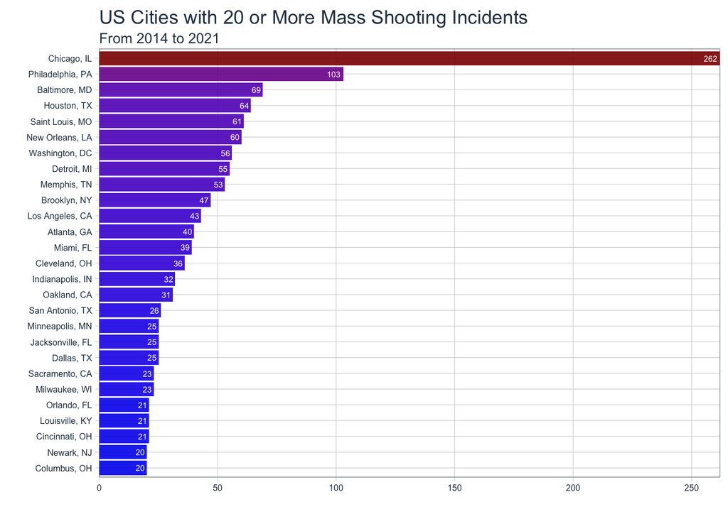

```r
ranked_cities %>%
    filter(number_incidents >= 20) %>%
    ggplot(aes(city, number_incidents, fill = number_incidents)) +
    geom_col(alpha = 0.9) +
    geom_text(aes(label = number_incidents), size = 2, color = "white", hjust = 1.2) +
    coord_flip() +
    scale_fill_gradient(low = "blue2", high = "red4") +
    scale_y_continuous(expand = c(0,0)) +
    theme_tq() +
    labs(x = "",
         y = "",
         title = str_glue("US Cities with 20 or More Mass Shooting Incidents"),
         subtitle = str_glue("From {ranked_cities$min_year} to {ranked_cities$max_year}")) +
    theme(legend.position = "none",
          axis.text.x = element_text(size = 6),
          axis.text.y = element_text(size = 6))
```

# Summary

What do we know so far?

Mass shootings incidents are increasing since 2014 at an average annual rate of 14%. Since 2020, the number of mass shootings has increased, and we appear to have a new higher ‘normal’ environment of mass shootings in the US.

Saturdays and Sundays tend to have more mass shootings, and account for about half of the mass shooting weekdays where Monday through Friday account for the remaining half.

Only 2 of fifty states since 2014 have not had a mass shooting - Hawaii and North Dakota.

The top five states (including Washington, DC) with the most total mass shootings since 2014 are Illinois, California, Texas, Florida, and Pennsylvania.

Per capita, Washington, D.C. experiences the most mass shootings, injuries, and deaths. This means that on a per person basis, you are more likely to experience a mass shooting in D.C., in fact, you are three times more likely than the next closest state which is Delaware in 2021.

D.C. is extraordinarily higher, not in total volume, but in the number of mass shootings per person in the D.C. population.  
Illinois, which is highest in total volume, also makes the list for states with the highest mass shootings, injuries, and deaths per capita. The other top volume states, California, Texas, Florida, and Pennsylvania do not share that distinction in 2021.